# Project 8

```r
# Add to this package list for additional SL algorithms
pacman::p_load(
  tidyverse,
  ggthemes,
  ltmle,
  tmle,
  SuperLearner,
  tidymodels,
  caret,
  dagitty,
  ggdag,
  here)

#install.packages("xgboost")
#install.packages("biglasso")
#install.packages("randomForest")


library("xgboost")
library("biglasso")
library("randomForest")
heart_disease <- read_csv(here('Project 8/heart_disease_tmle.csv'))
set.seed(283)
```

# Introduction

Heart disease is the leading cause of death in the United States, and treating it properly is an important public health goal. However, it is a complex disease with several different risk factors and potential treatments. Physicians typically recommend changes in diet, increased exercise, and/or medication to treat symptoms, but it is difficult to determine how effective any one of these factors is in treating the disease. In this project, you will explore SuperLearner, Targeted Maximum Likelihood Estimation (TMLE), and Longitudinal Targeted Maximum Likelihood Estimation (LTMLE). Using a simulated dataset, you will explore whether taking blood pressure medication reduces mortality risk.

# Data

For the “SuperLearner” and “TMLE” portions, you can ignore any variable that ends in “_2”, we will reintroduce these for LTMLE.

# SuperLearner

## Modeling

Fit a SuperLearner model to estimate the probability of someone dying from complications of heart disease, conditional on treatment and the relevant covariates. Do the following:

```r
# Fit SuperLearner Model

## sl lib

listWrappers()
```

```
## All prediction algorithm wrappers in SuperLearner:
```

```
##  [1] "SL.bartMachine"      "SL.bayesglm"         "SL.biglasso"
##  [4] "SL.caret"            "SL.caret.rpart"      "SL.cforest"
##  [7] "SL.earth"            "SL.gam"              "SL.gbm"
## [10] "SL.glm"              "SL.glm.interaction"  "SL.glmnet"
## [13] "SL.ipredbagg"        "SL.kernelKnn"        "SL.knn"
## [16] "SL.ksvm"             "SL.lda"              "SL.leekasso"
## [19] "SL.lm"               "SL.loess"            "SL.logreg"
## [22] "SL.mean"             "SL.nnet"             "SL.nnls"
## [25] "SL.polymars"         "SL.qda"              "SL.randomForest"
## [28] "SL.ranger"           "SL.ridge"            "SL.rpart"
## [31] "SL.rpartPrune"       "SL.speedglm"         "SL.speedlm"
## [34] "SL.step"             "SL.step.forward"     "SL.step.interaction"
## [37] "SL.stepAIC"          "SL.svm"              "SL.template"
## [40] "SL.xgboost"
```

```
##
## All screening algorithm wrappers in SuperLearner:
```

```
## [1] "All"
## [1] "screen.corP"           "screen.corRank"        "screen.glmnet"
## [4] "screen.randomForest"   "screen.SIS"            "screen.template"
## [7] "screen.ttest"          "write.screen.template"
```

```r
# set seed
set.seed(987)

# multiple models
# ----------
 # I chose the following models: 'SL.mean','SL.glmnet','SL.randomForest','SL.glm','SL.xgboost','SL.biglasso')
```

```r
## Train/Test split
# initial split
# ----------
heart_split <-
  initial_split(heart_disease, prop = 3/4) # create initial split (tidymodels)

train <- training(heart_split)

# y_train
y_train <-
  train  %>%
  # pull and save as vector
  pull(mortality)

# x_train
x_train <-
  train %>%
  # drop the target variable
  select(-mortality)

# Testing
# ----------
test <-
  # Declare the training set with rsample::training()
  testing(heart_split)

# y test
y_test <-
  test %>%
  pull(mortality)

# x test
x_test <-
  test %>%
  select(-mortality)
```

```r
## Train SuperLearner

# I'm doing 4 because it is taking a long time to process
sl_libs <- c('SL.mean','SL.randomForest','SL.glm', 'xgboost')

sl = SuperLearner(Y = y_train,
                  X = x_train,
                  family = binomial(),
                  # notice these models are concatenated
                  SL.library = c('SL.mean',    # if you just guessed the average - serves as a baseline
                                 'SL.glm',
                                 'SL.randomForest' ))

## Risk and Coefficient of each model
sl
```

```
##
## Call:
## SuperLearner(Y = y_train, X = x_train, family = binomial(), SL.library = c("SL.mean",
##     "SL.glm", "SL.randomForest"))
##
##
##                          Risk      Coef
## SL.mean_All         0.2497082 0.0266211
## SL.glm_All          0.2355568 0.3449418
## SL.randomForest_All 0.2312765 0.6284371
```

```r
## Discrete winner and superlearner ensemble performance

# predictions
# ----------
preds <-
  predict(sl,             # use the superlearner not individual models
          x_test,         # prediction on test set
          onlySL = TRUE)  # use only models that were found to be useful (had weights)


# start with y_test
validation <-
  y_test %>%
  # add our predictions - first column of predictions
  bind_cols(preds$pred[,1]) %>%
  # rename columns
  rename(obs = `...1`,      # actual observations
         pred = `...2`) %>% # predicted prob
  # change pred column so that obs above .5 are 1, otherwise 0
  mutate(pred = ifelse(pred >= .5,
                           1,
                           0))
# view
head(validation)
```

```
## # A tibble: 6 × 2
##     obs  pred
##   <dbl> <dbl>
## 1     1     1
## 2     0     1
## 3     1     1
## 4     1     1
## 5     0     1
## 6     1     1
```

```r
## Confusion Matrix
```

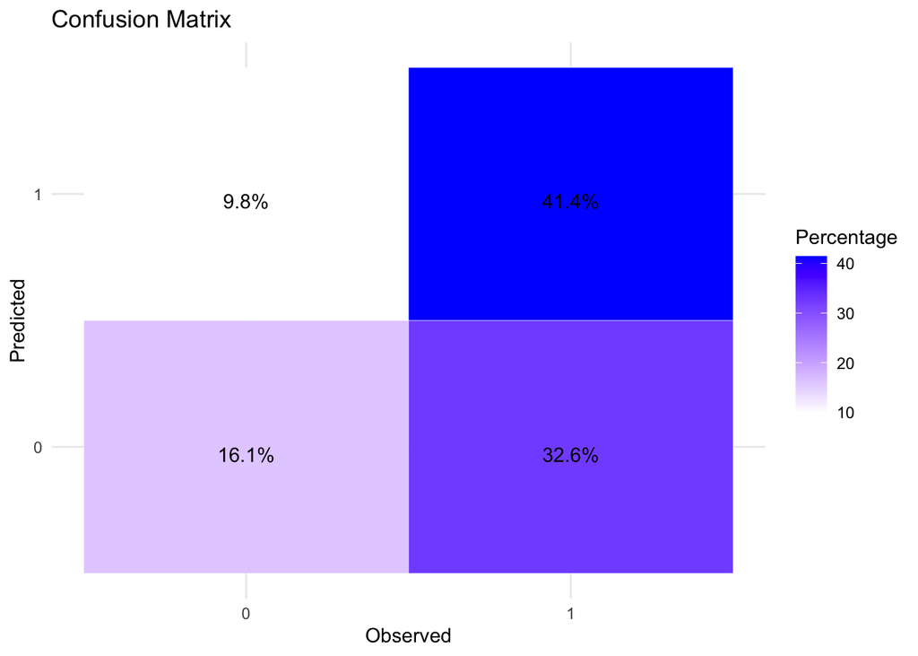

```r
# confusion matrix
# ----------
conf_matrix <- confusionMatrix(as.factor(validation$pred),
                               as.factor(validation$obs))


# Extract the table from the confusion matrix
matrix_data <- as.data.frame(as.table(conf_matrix$table))

# Rename the columns for easier understanding
colnames(matrix_data) <- c("Reference", "Prediction", "Frequency")

# Convert frequencies to percentages
total_observations <- sum(matrix_data$Frequency)
matrix_data$Percentage <- (matrix_data$Frequency / total_observations) * 100

# Plot using ggplot2 with percentages
ggplot(matrix_data, aes(x = Reference, y = Prediction, fill = Percentage)) +
  geom_tile(color = "white") + # Use geom_tile for the heatmap effect
  scale_fill_gradient(low = "white", high = "blue") + # Color gradient
  geom_text(aes(label = sprintf("%.1f%%", Percentage)), vjust = 1) + # Add percentage text
  theme_minimal() + # Use a minimal theme
  labs(title = "Confusion Matrix", x = "Observed", y = "Predicted") # Labels
```

```r
overall_stats <- conf_matrix$overall
accuracy <- overall_stats['Accuracy']
precision <- overall_stats['Precision']
recall <- overall_stats['Recall']
F1 <- 2 * (precision * recall) / (precision + recall)

# Display the metrics
cat("Accuracy: ", accuracy * 100, "%\n")
```

```
## Accuracy:  57.56 %
```

```r
cat("Precision: ", precision * 100, "%\n")
```

```
## Precision:  NA %
```

```r
cat("Recall: ", recall * 100, "%\n")
```

```
## Recall:  NA %
```

```r
cat("F1 Score: ", F1 * 100, "%\n")
```

```
## F1 Score:  NA %
```

# Targeted Maximum Likelihood Estimation

## Causal Diagram

Using ggdag and daggity, draw a directed acylcic graph (DAG) that describes the relationships between the outcome, treatment, and covariates/predictors. Note, if you think there are covariates that are not related to other variables in the dataset, note this by either including them as freestanding nodes or by omitting them and noting omissions in your discussion.

W = age, sex_at_birth, simplified_race, income_thousands, college_educ, bmi, chol, blood_pressure A = blood_pressure_medication Y = mortality Uw = unobserved variables affecting covariates Ua = unobserved variables affecting treatment

Notice that almost all covariets have an effect on the prescription and take-up of the medication: due to guidelines we know there are differential recomemndations based on age, sex, race, and bmi, chol, blood presure levels; and then we see that education, income also play a role in how many people will follow the treatment and adhere.

Similarly, all these variables are related to mortality

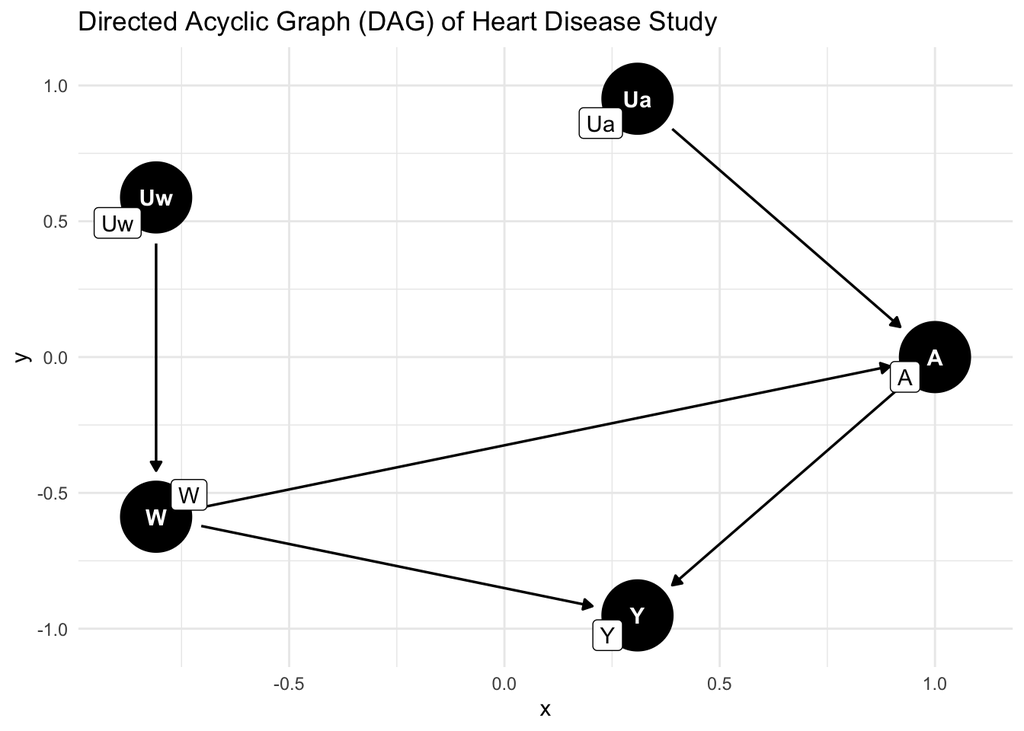

```r
# DAG for TMLE
library(ggdag)
library(dagitty)

# Define DAG

dag <- dagitty::dagitty("
dag {
  Uw [unobserved]
  Ua [unobserved]
  W -> A -> Y
  W -> Y
  Uw -> W
  Ua -> A
}
")

ggdag <- ggdag::ggdag(dag, text = TRUE, use_labels = "name", layout = "circle") +
  theme_minimal() +
  ggtitle("Directed Acyclic Graph (DAG) of Heart Disease Study")

print(ggdag)
```

## TMLE Estimation

Use the `tmle` package to estimate a model for the effect of blood pressure medication on the probability of mortality. Do the following:

```r
# set seed for reproducibility
set.seed(1000)
sl_libs <- c('SL.mean','SL.randomForest','SL.glm', 'xgboost')


# Define the outcome, treatment, and covariates
Y <- "mortality"
A <- "blood_pressure_medication"
W <- c("age", "sex_at_birth", "simplified_race", "income_thousands", "college_educ", "bmi", "chol", "blood_pressure")  #

# Run the TMLE
tmle_fit <- tmle(
  Y = heart_disease[[Y]],
  A = heart_disease[[A]],
  W = heart_disease[W],
  family = "binomial",  # assuming Y is binary
  Q.SL.library = sl_libs,
  g.SL.library = sl_libs
)
```

[output not shown]

```r
# view results
tmle_fit
```

```
##  Additive Effect
##    Parameter Estimate:  -0.35362
##    Estimated Variance:  6.1067e-05
##               p-value:  <2e-16
##     95% Conf Interval:  (-0.36893, -0.3383)
##
##  Additive Effect among the Treated
##    Parameter Estimate:  -0.31436
##    Estimated Variance:  0.00014364
##               p-value:  <2e-16
##     95% Conf Interval:  (-0.33785, -0.29087)
##
##  Additive Effect among the Controls
##    Parameter Estimate:  -0.35925
##    Estimated Variance:  5.4449e-05
##               p-value:  <2e-16
##     95% Conf Interval:  (-0.37372, -0.34479)
##
##  Relative Risk
##    Parameter  Estimate: 0.37582
##    Variance(log scale): 0.00082192
##                p-value: <2e-16
##      95% Conf Interval: (0.35529, 0.39754)
##
##  Odds Ratio
##    Parameter  Estimate: 0.20697
##    Variance(log scale): 0.0016466
##                p-value: <2e-16
##      95% Conf Interval: (0.19115, 0.22411)
```

# LTMLE Estimation

Now imagine that everything you measured up until now was in “time period 1”. Some people either choose not to or otherwise lack access to medication in that time period, but do start taking the medication in time period 2. Imagine we measure covariates like BMI, blood pressure, and cholesterol at that time for everyone in the study (indicated by a “_2” after the covariate name).

## Causal Diagram

Update your causal diagram to incorporate this new information. : If your groups divides up sections and someone is working on LTMLE separately from TMLE then just draw a causal diagram even if it does not match the one you specified above.

: Check out slide 27 from Maya’s lecture, or slides 15-17 from Dave’s second slide deck in week 8 on matching.

: Keep in mind that any of the variables that end in “_2” are likely affected by both the previous covariates and the first treatment when drawing your DAG.

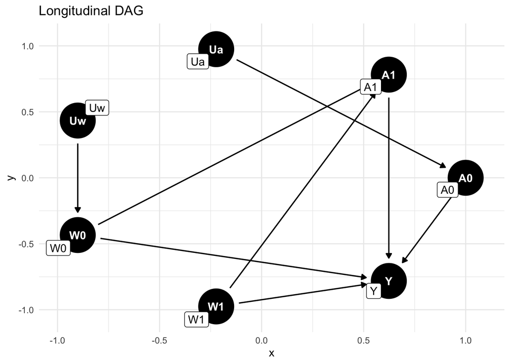

```r
# DAG for TMLE


dag <- dagitty::dagitty("
dag {
  Uw [unobserved]
  Ua [unobserved]
  W1-> A1 -> Y
  W1 -> Y
  W0 -> Y
  W0 -> A1
  A0 -> Y
  Uw -> W0
  Ua -> A0
}
")

ggdag <- ggdag::ggdag(dag, text = TRUE, use_labels = "name", layout = "circle") +
  theme_minimal() +
  ggtitle("Longitudinal DAG")

# Print the DAG
print(ggdag)
```

## LTMLE Estimation

Use the `ltmle` package for this section. First fit a “naive model” that control for the time-dependent confounding. Then run a LTMLE model that does control for any time dependent confounding. Follow the same steps as in the TMLE section. Do you see a difference between the two estimates?

```r
## Naive Model (no time-dependent confounding) estimate


data_obs <-
  heart_disease %>%
  rename(Y = mortality, A = blood_pressure_medication, W1=age, W2=sex_at_birth, W3=simplified_race, W4=college_educ, W5=income_thousands, W6=bmi, W7=blood_pressure, W8=chol)

data_obs_ltmle <-
  data_obs %>%
  select(W1, W2, W3,W4,W5,W6,W7,W8, A, Y)

# implement ltmle
# ----------
result <- ltmle(data_obs_ltmle, # dataset
                Anodes = "A",   # vector that shows treatment
                Ynodes = "Y",   # vector that shows outcome
                abar = 1)
```

```
## Qform not specified, using defaults:
```

```
## formula for Y:
```

```
## Q.kplus1 ~ W1 + W2 + W3 + W4 + W5 + W6 + W7 + W8 + A
```

```
## gform not specified, using defaults:
```

```
## formula for A:
```

```
## A ~ W1 + W2 + W3 + W4 + W5 + W6 + W7 + W8
```

```
## Estimate of time to completion: < 1 minute
```

```r
# view
result
```

```
## Call:
## ltmle(data = data_obs_ltmle, Anodes = "A", Ynodes = "Y", abar = 1)
##
## TMLE Estimate:  0.2041733
```

## LTMLE estimate

```r
# implement ltmle
set.seed(125)
sl_libs <- c('SL.mean','SL.glm', 'SL.xgboost', 'randomForest')

# Create and rename
data <- heart_disease %>%
  rename(Y = mortality,
         A1 = blood_pressure_medication,
         A2 = blood_pressure_medication_2,
         W1 = age, W2 = sex_at_birth,
         W3 = simplified_race,
         W4 = college_educ,
         W5 = income_thousands,
         W6 = bmi, W7 = blood_pressure,
         W8 = chol,
         L1 = bmi_2,
         L2 = blood_pressure_2,
         L3 = chol_2)

# Check if data_ is a data frame (needed from ltmle code)
print(is.data.frame(data))
```

```
## [1] TRUE
```

```r
ltmle_res <- ltmle(data,
      Anodes = c("A1", "A2"),  # Two treatment variables
      Lnodes = c("L1", "L2", "L3"),  # L indicators
      Ynodes = "Y",  # Outcome
      abar = c(1, 1),  # Treatment indicator in Anodes vector
      SL.library = sl_libs)
```

```
## Qform not specified, using defaults:
```

```
## formula for L1:
```

```
## Q.kplus1 ~ W1 + W2 + W3 + W4 + W5 + W6 + W7 + W8 + A1
```

```
## formula for Y:
```

```
## Q.kplus1 ~ W1 + W2 + W3 + W4 + W5 + W6 + W7 + W8 + A1 + L1 +     L2 + L3 + A2
```

```
## gform not specified, using defaults:
```

```
## formula for A1:
```

```
## A1 ~ W1 + W2 + W3 + W4 + W5 + W6 + W7 + W8
```

```
## formula for A2:
```

```
## A2 ~ W1 + W2 + W3 + W4 + W5 + W6 + W7 + W8 + A1 + L1 + L2 + L3
```

[output not shown]

[output cut: 11 more lines]

[output not shown]

```
## Estimate of time to completion: 3 to 7 minutes
```

[output not shown]

[output not shown]

[output not shown]

[output not shown]

[output not shown]

[output not shown]

[output not shown]

[output not shown]

[output not shown]

[output not shown]

[output not shown]

[output not shown]

[output not shown]

[output not shown]

[output not shown]

[output not shown]

[output not shown]

[output not shown]

[output not shown]

[output not shown]

[output not shown]

[output not shown]

[output not shown]

[output not shown]

[output not shown]

[output not shown]

[output not shown]

[output not shown]

[output not shown]

[output not shown]

[output not shown]

[output not shown]

[output not shown]

[output not shown]

[output not shown]

[output not shown]

[output not shown]

[output not shown]

[output not shown]

[output not shown]

[output not shown]

[output not shown]

[output not shown]

[output not shown]